# Calculating (Twitter) Vocabulary Breadth of U.S. Presidential Candidates Using TTR

Tim Wilson (@tgwilson)

A recent podcast referenced Donald Trump’s limited vocabulary in his tweets (I honestly don’t remember exactly which one). The implication was that, relatively speaking, he used a limited number of unique words. This led me to wonder how that could be quantified and checked. Which, as tends to happen, led to a passing discussion with [Joe Sutherland](https://twitter.com/J0eSutherland), the head of data science at [Search Discovery](https://searchdiscovery.com), and he immediately noted, “That sounds like a TTR question.” And he was right (I’d never heard of TTR, but, then again, I’m not a data scientist nor an NLP expert).

That little [If You Give a Pig a Pancake](https://www.amazon.com/If-You-Give-Pig-Pancake/dp/0060266864) scenario then resulted in some research, some R, the remainder of this post, and my [podcast](https://analyticshour.io) co-hosts questioning how I choose to spend my free time on the weekends.

## What is TTR?

The Type-Token Ratio (TTR) is a pretty simple calculation. It is a measure of how many *unique* words are used in a corpus relative to the *total* words in the corpus. There is a detailed write-up of the process [here](https://www.sltinfo.com/type-token-ratio/), but the formula is really simple:

$$\frac{Number\ of\ Unique\ Words}{Total\ Words}\times100$$

As a silly, simple example, let’s use: `The quick brown fox jumps over the lazy dog`. The word “the” is the only word used more than once in this sentence.

$${Number\ of\ Unique\ Words}=8$$
$${Total\ Words}=9$$
$${TTR}=\frac{8}{9}\times100=88.9\%$$
A **low TTR** means that *there are more words that are used again and again* in the data, while a **high TTR** (maximum of 100%) means that *few words are repeated in the dataset*.

Calculating the TTR just for Trump’s tweets would just return a percentage, which wouldn’t be particularly enlightening. I’d need some context. So, I also calculated the TTR for the 12 Democratic candidates who have made the cut to be on the Democratic debate stage on October 15, 2019.

## Setup to Get the Data

There’s a little bit of setup required to use `rtweet`, in that a (free) app has to be created in the [Twitter Developer Console](https://developer.twitter.com/en/apps). The credentials for that app can then be stored in a `.Renviron` file and then read in with `Sys.getenv()`.

And, to make the code repurposable, we specify a single Twitter account that is the primary account of interest, and then a vector of accounts to use for context/comparison.

```r
# Load the necessary libraries.
if (!require("pacman")) install.packages("pacman")
pacman::p_load(rtweet,        # How we actually get the Twitter data
               tidyverse,
               scales,        # % formatting in visualizations
               knitr,         # Eye-friendly tables
               ggforce,       # Simpler labels on a scatterplot
               tidytext)      # Text analysis

# Set the number of tweets to use. We'll pull 2.5X that number of tweets
num_tweets <- 200

# Set users to assess
user_highlight <- "realdonaldtrump"   # The primary user of interest for comparison
users_compare <- c("joebiden", "corybooker", "petebuttigieg", "juliancastro",
                   "tulsigabbard", "kamalaharris", "amyklobuchar", "betoorourke",
                   "sensanders", "tomsteyer", "ewarren", "andrewyang")

# Make a vector of all users to query
users <- c(user_highlight, users_compare)

# Add the "@" to the user_highlight for ease of use later
user_highlight <- paste0("@", user_highlight)

# Create the token.
tw_token <- create_token(
  app = Sys.getenv("TWITTER_APPNAME"),
  consumer_key = Sys.getenv("TWITTER_KEY"),
  consumer_secret = Sys.getenv("TWITTER_SECRET"),
  access_token = Sys.getenv("TWITTER_ACCESS_TOKEN"),
  access_secret = Sys.getenv("TWITTER_ACCESS_SECRET"))

# Go ahead and set up the theme we'll use for the visualizations
theme_main <- theme_light() +
  theme(plot.title = element_text(hjust = 0.5, face = "bold", size = 24),
        plot.subtitle = element_text(hjust = 0.5, face = "italic", size = 20),
        panel.border = element_blank(),
        axis.title = element_blank(),
        axis.text.y = element_text(face = "bold", size = 20),
        axis.text.x = element_blank(),
        axis.ticks = element_blank(),
        panel.grid = element_blank())
```

## Function to Calculate the TTR

Ultimately, we’re looking for 200 tweets of original text (there’s no magic to this – it just seemed like a reasonable count to work with), so we pull ~500, remove the retweets, and see what we’ve got left. Because we’re going to do this for multiple accounts, we set it up as a function that takes a username as an input and returns a single-row data frame with the username, the total words used in the 200 tweets, the number of *unique* words used in those tweets, the TTR, and a couple of data checks.

```r
# Function to calculate the TTR
get_ttr <- function(username){

  # Get the tweets. W want extras so we can discard retweets and
  # still have at least num_tweets left.
  tweets_df <- get_timeline(username, n=num_tweets*2.5)

  # Remove the retweets, remove tweets from the current day for ease o
  # replicability, and select the most recent num_tweets remaining tweets
  tweets_df <- tweets_df %>%
    filter(is_retweet == FALSE & as.Date(created_at) < Sys.Date()) %>%
    top_n(n = num_tweets, wt = created_at)

  # Work with just the text field. Remove Twitter usernames referenced
  # and links.
  tweets_text <- tweets_df %>%
    select(text) %>%
    mutate(text = gsub("@\\S+","", text)) %>%
    mutate(text = gsub("https://t.co/.{10}", "", text))

  # Convert the tweet text into individual words. This drops punctuation
  # marks and, by default, converts all words to lowercase (which is what we want).
  all_words <- tweets_text %>%
    unnest_tokens(output=word, input=text)

  # De-duplicate to get a list with the unique words
  unique_words <- all_words %>%
    group_by(word) %>%
    summarise()

  # Calculate the TTR
  ttr <- nrow(unique_words) / nrow(all_words)

  # Return a data frame with the details. Include the # of tweets -- to check
  # for any API glithces -- and the timespan covered by the tweets
  ttr_df <- data.frame(username = paste0("@",username),
                       unique_words = nrow(unique_words),
                       all_words = nrow(all_words),
                       ttr = round(ttr,3),
                       num_tweets = nrow(tweets_df),
                       timespan_days = as.numeric(difftime(max(tweets_df$created_at),
                                                           min(tweets_df$created_at),
                                                           units = "days")),
                       stringsAsFactors = FALSE)
}
```

# Get the Results

This is now pretty easy – just call our function for all of the users.

```r
# Calculate the TTR for all users
ttr_df <- map_dfr(users, get_ttr)

# Reorder descending by TTR and add columns that are JUST @realdonaldtrump
# values for highlighting those values in plots
ttr_df <- ttr_df %>% arrange(ttr) %>%
  mutate(username = factor(username, levels = username),
         highlight_ttr = ifelse(username == user_highlight, ttr, NA),
         highlight_unique_words = ifelse(username == user_highlight, unique_words, NA),
         highlight_all_words = ifelse(username == user_highlight, all_words, NA))

# Take a quick look at the data
ttr_df %>% select(username, unique_words, all_words, ttr, num_tweets, timespan_days) %>% kable()
```

| username | unique_words | all_words | ttr | num_tweets | timespan_days |
| --- | --- | --- | --- | --- | --- |
| @betoorourke | 1508 | 6339 | 0.238 | 200 | 22.826123 |
| @ewarren | 1509 | 6305 | 0.239 | 200 | 11.258715 |
| @joebiden | 1601 | 6533 | 0.245 | 200 | 22.968681 |
| @tulsigabbard | 1461 | 5836 | 0.250 | 200 | 65.765903 |
| @sensanders | 2063 | 8011 | 0.258 | 200 | 69.070301 |
| @corybooker | 1557 | 5899 | 0.264 | 200 | 27.884745 |
| @amyklobuchar | 1612 | 6053 | 0.266 | 200 | 27.277882 |
| @realdonaldtrump | 1259 | 4707 | 0.267 | 200 | 9.017720 |
| @tomsteyer | 1401 | 5224 | 0.268 | 200 | 26.900104 |
| @petebuttigieg | 1527 | 5646 | 0.270 | 200 | 41.230324 |
| @kamalaharris | 1555 | 5448 | 0.285 | 200 | 22.152083 |
| @juliancastro | 1598 | 5161 | 0.310 | 200 | 16.035116 |
| @andrewyang | 965 | 2764 | 0.349 | 200 | 8.161887 |

The `timespan_days` was a later addition to this analysis, but it shows how many days it took for the candidate to tweet 200 times (not counting retweets, but this includes both straight-up original tweets and replies to other tweets). There is quite a range there!

## Analysis of the Results

We can start with a simple bar chart showing the TTR for each user.

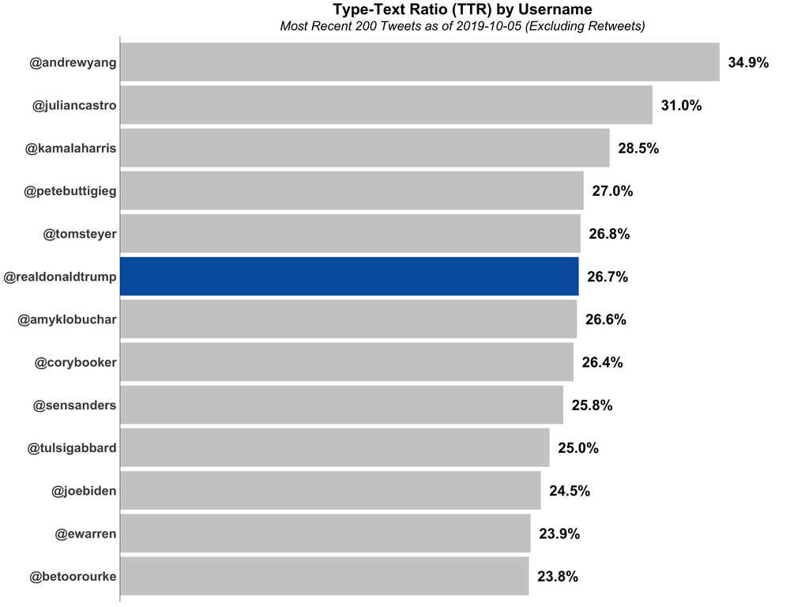

```r
gg <- ggplot(ttr_df, aes(x = username, y = ttr, label = scales::percent(ttr))) +
  geom_bar(stat = "identity", fill = "gray80") +
  # Highlight the user that is of interest
  geom_bar(stat = "identity", mapping = aes(y = highlight_ttr), fill = "#0060af") +
  geom_text(nudge_y = 0.005, size = 8, fontface = "bold", hjust = 0) +
  geom_hline(yintercept = 0) +
  coord_flip() +
  scale_y_continuous(expand = c(0,0), limits = c(0, max(ttr_df$ttr) + 0.05)) +
  labs(title = "Type-Text Ratio (TTR) by Username",
       subtitle = paste("Most Recent", num_tweets,"Tweets as of", Sys.Date()-1,
                        "(Excluding Retweets)")) +
  theme_main
gg
```

Alas! Nothing dramatic. It appears that anyone who wants to claim Trump has a troglodytian vocabulary in his tweets…well…will have to dig deeper and use either a different methodology or a different comparison set. Actually, by this measure, arguably the *most* erudite and wonky of the Democratic frontrunners, Elizabeth Warren (@ewarren), has one of the *lowest* TTRs in her tweets.

At the same time, Andrew Yang, who is arguably one of the *most* single-issue (UBI) candidates remaining in race, has the highest TTR, when one might expect that he would be *more* prone to repeating the same words more often in his tweets.

If we dig a little deeper, we can look at the raw word volume used in the tweets. Since we worked with “200 tweets,” and a tweet is constrained to 280 characters, there are some natural constraints within the data, but the different candidates actually bump up against those constraints in differents ways.

So, let’s look at the *total words* across the 200 tweets from each user (keeping the users in the same order for comparison purposes):

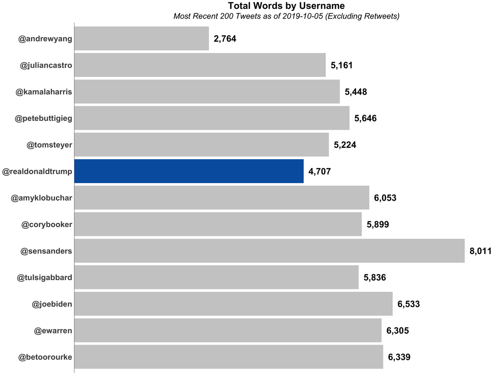

```r
gg <- ggplot(ttr_df, aes(x = username, y = all_words, label = scales::comma(all_words))) +
  geom_bar(stat = "identity", fill = "gray80") +
  # Highlight the user that is of interest
  geom_bar(stat = "identity", mapping = aes(y = highlight_all_words), fill = "#0060af") +
  geom_text(nudge_y = 100, size = 8, fontface = "bold", hjust = 0) +
  geom_hline(yintercept = 0) +
  coord_flip() +
  scale_y_continuous(expand = c(0,0), limits = c(0, max(ttr_df$all_words) + 700)) +
  labs(title = "Total Words by Username",
       subtitle = paste("Most Recent", num_tweets,"Tweets as of", Sys.Date()-1,
                        "(Excluding Retweets)")) +
  theme_main
gg
```

Now we see that Andrew Yang, who had the highest TTR, also had far and away the *lowest* number of individual words across our sample of 200 tweets. Trump came in a fairly distant – but solid – second. For Trump, this lines up somewhat with my impression of many of his tweets being fairly pithy proclamations (although these are mixed in with multi-tweet rants, too).

A visual inspection of Yang’s Twitter feed turns up that he is actually brevity-biased, with quick notes and thoughts that cross his mind (e.g., [“Why do I feel like I have to see Joker.”](https://twitter.com/AndrewYang/status/1180600460098424832) – brief and punctuation-challenged to boot.)

On the other extreme, Bernie Sanders had far and away the *most* words across his most recent 200 tweets. A manual inspection of his Twitter feed shows that, unlike Yang, his tweets are fully formed thoughts/commentary about the various issues that are at the core of his platform (often commenting on current events and making the link to his proposed policies…which requires more words than an idle musing).

> **Side Note:** From the table above, Yang and Trump were the two “fastest to 200” users. Sanders was actually the slowest to hit that volume of non-retweet tweets.

Is there an obvious relationship between the volume of overall words and the TTR? Scatterplot, here we come:

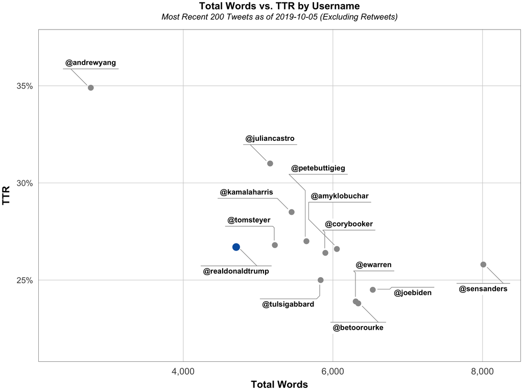

```r
gg <- ggplot(ttr_df, aes(x = all_words, y = ttr, label = username)) +
  # A handy ggforce function to get annotations on a static scatterplot
  geom_mark_circle(mapping = aes(fill = username), alpha = 0, color = NA,
                   label.fontsize = 18, expand = 0.01,
                   con.cap = 0, con.colour = "gray50",
                   show.legend = FALSE) +
  geom_point(stat = "identity", color = "gray60", size = 6) +
  # Highlight the user that is of interest
  geom_point(stat = "identity", mapping = aes(x = highlight_all_words,
                                              y = highlight_ttr),
             color = "#0060af", size = 8) +
  scale_x_continuous(expand = c(0,0), limits = c(min(ttr_df$all_words) - 700,
                                                 max(ttr_df$all_words) + 500),
                     labels = scales::comma) +
  scale_y_continuous(expand = c(0,0), limits = c(min(ttr_df$ttr) - 0.03,
                                                 max(ttr_df$ttr) + 0.03),
                     labels = scales::percent_format(accuracy=1)) +
  labs(title = "Total Words vs. TTR by Username",
      subtitle = paste("Most Recent", num_tweets,"Tweets as of", Sys.Date()-1,
                        "(Excluding Retweets)")) +
  xlab("Total Words") +
  ylab("TTR") +
  theme_main +
  theme(plot.subtitle = element_text(margin = margin(0,0,20,0)),
        panel.border = element_rect(color = "black", fill = NA),
        panel.grid.major = element_line(color = "gray80"),
        axis.title = element_text(size = 24, face = "bold"),
        axis.text.x = element_text(size = 22, margin = margin(10,0,10,0)),
        axis.text.y = element_text(face="plain", margin = margin(0,10,0,10)))
gg
```

Interesting. And, logically, this makes some sense: the more words you use, the more likely you will be going back to the well of previous words used (plus, the more you’ll be using common articles, prepositions, conjuctions, etc.). It’s starting to look like there *might* be an inverse correlation. Andrew Yang may be an outlier on that front (as might be Bernie Sanders). But, let’s do a simple check of the correlation coefficient with and without the outliers.

The correlation coefficient between `Total Words` and `TTR` for all users is **-0.7868562**.

But, if we check the correlation coefficient between `Total Words` and `TTR` with Andrew Yang *excluded*, it drops to a mere **-0.5081672**.

If we remove both Andrew Yang *and* Bernie Sanders, then the correlation coefficient jumps back up to **-0.7011596**.

We’re not working with very many data points here, so we’re veering into dangerous data cherrypicking territory at this point, and really should not do that!

## Conclusions

In general, Donald Trump uses fewer words per tweet than any of the Democratic presidential hopefuls, with Andrew Yang being a notable exception.

When it comes to the number of *unique words* Trump uses in Tweets as normalized by the total words he uses, he’s pretty much middle of the road with those candidates.

And, of course, I had to check where I, personally, netted out, so I ran the analysis on @tgwilson, too. I came out with a **TTR of 35.5%** (which is above even Yang) with **4,642 total words**, which is a dead heat with Trump. If I’d thrown myself into the correlation assessment, it would have simply muddied the waters further.

I like TTR, though. It’s a simple idea, simple to calculate (it’s even a function in the `koRpus` package, but it’s so easy to calculate that it didn’t seem warranted to add another package to the mix), and straightforward to interpret.